# ningze_sun_hw3

```r
library(tidyverse)
library(dplyr)
library(ggplot2)
library(reshape2)
library(ggpubr)
theme_set(theme_pubr())
library(manipulate)
library(patchwork)
library(infer)
library(broom)


labels_make = function(linear, x = 'Brain_Size_Species_Mean'){
  linear_res = linear[["coefficients"]]
  slope = linear_res[[x]]
  intercept = linear_res[['(Intercept)']]
  labels = paste("E[Y|X] =", toString(round(slope, digits = 3)), "X +",
                 toString(round(intercept, digits = 3)))
  return(list(slope = slope, intercept = intercept, labels = labels))
}


cal_ci = function(means, std, n, conf = 0.975){
  error = qnorm(conf) * std / sqrt(n)
  return(c(means - error, means + error))
}
```

## Challenge 1

Fit a simple linear regression model to predict weaning age (WeaningAge_d) measured in days from species’ brain size (Brain_Size_Species_Mean) measured in grams.

Try both models: weaning age ~ brain size and log(weaning age) ~ log(brain size).

### 1

I did it by lm function and produce a scatterplot with the fitted line superimposed upon the data

For weaning age ~ brain size model

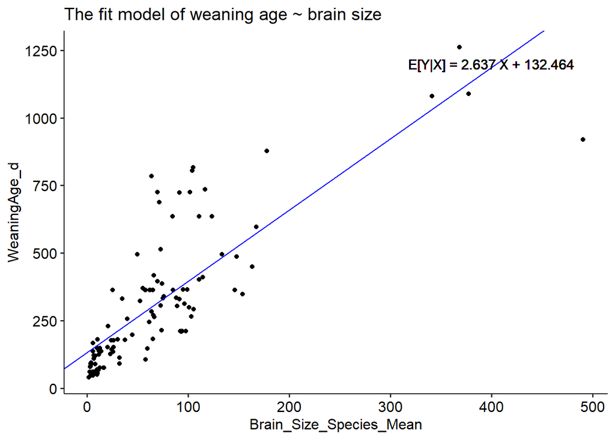

```r
df = as_tibble(read.csv("KamilarAndCooperData.csv"))
df_lm = df[c("WeaningAge_d", "Brain_Size_Species_Mean")] %>% drop_na()
linear = lm(WeaningAge_d ~ Brain_Size_Species_Mean, data = df_lm)
linear_res = labels_make(linear)
ggplot(data = df_lm, aes(x = Brain_Size_Species_Mean, y = WeaningAge_d)) + geom_point() +
  geom_abline(intercept = linear_res[['intercept']], slope = linear_res[['slope']], col = 'blue') +
  geom_text(x = 400, y = 1200, label = linear_res[['labels']], size = 4) +
  ggtitle("The fit model of weaning age ~ brain size")
```

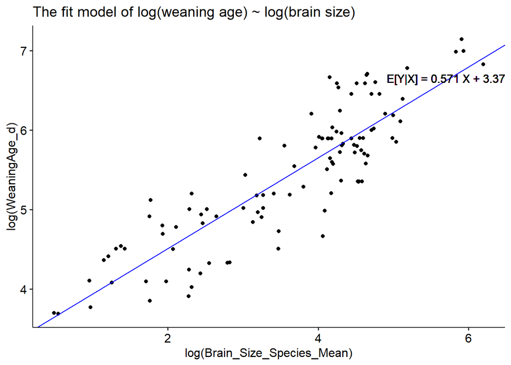

```r
log_linear = lm(log(WeaningAge_d) ~ log(Brain_Size_Species_Mean), data = df_lm)
log_linear_res = labels_make(log_linear, x = 'log(Brain_Size_Species_Mean)')

ggplot(data = df_lm, aes(x = log(Brain_Size_Species_Mean), y = log(WeaningAge_d))) + geom_point() +
  geom_abline(intercept = log_linear_res[['intercept']], slope = log_linear_res[['slope']], col = 'blue') +
  geom_text(x = 5.7, y = 6.65, label = log_linear_res[['labels']], size = 4) +
  ggtitle("The fit model of log(weaning age) ~ log(brain size)")
```

### 2

Identify and interpret the point estimate of the slope, as well as the outcome of the test associated with the hypotheses. Also, find a 90% CI for the slope parameter.

```r
b = summary(linear)[['coefficients']][[2]]
b_log = summary(log_linear)[['coefficients']][[2]]
print(paste("regular model's estimated beta_1 is", toString(b), ", log model's estimated beta_1 is", toString(b_log)))
```

```
## [1] "regular model's estimated beta_1 is 2.63710671910417 , log model's estimated beta_1 is 0.571159985122829"
```

For explanation of beta_1:

in regular model with one unit of brain size increasing, the average of weaning age increases by around 2.637.

in log model, with one unit of log(brain size) increase, the average of log(weaning age) increases by around 0.571

```r
b_t = tidy(linear)
b_log_t = tidy(log_linear)
linear_ci = confint(linear, "Brain_Size_Species_Mean", level = 0.9)
log_linear_ci = confint(log_linear, "log(Brain_Size_Species_Mean)", level = 0.9)
print(paste("t value of regular model of beta_1 is ", toString(b_t[['statistic']][[2]])))
```

```
## [1] "t value of regular model of beta_1 is  14.275844514277"
```

```r
print(paste("t value of log model of beta_1 is ", toString(b_log_t[['statistic']][[2]])))
```

```
## [1] "t value of log model of beta_1 is  18.6614949112865"
```

```r
print(paste("p value of regular model of beta_1 is ", toString(b_t[['p.value']][[2]])))
```

```
## [1] "p value of regular model of beta_1 is  1.58533834049724e-26"
```

```r
print(paste("p value of log model of beta_1 is ", toString(b_log_t[['p.value']][[2]])))
```

```
## [1] "p value of log model of beta_1 is  1.98968952247998e-35"
```

```r
print(paste("CI of beta_1 of regular model is ", toString(linear_ci)))
```

```
## [1] "CI of beta_1 of regular model is  2.33060727583459, 2.94360616237375"
```

```r
print(paste("CI of beta_1 of log model is ", toString(log_linear_ci)))
```

```
## [1] "CI of beta_1 of log model is  0.520377361222942, 0.621942609022716"
```

### 3

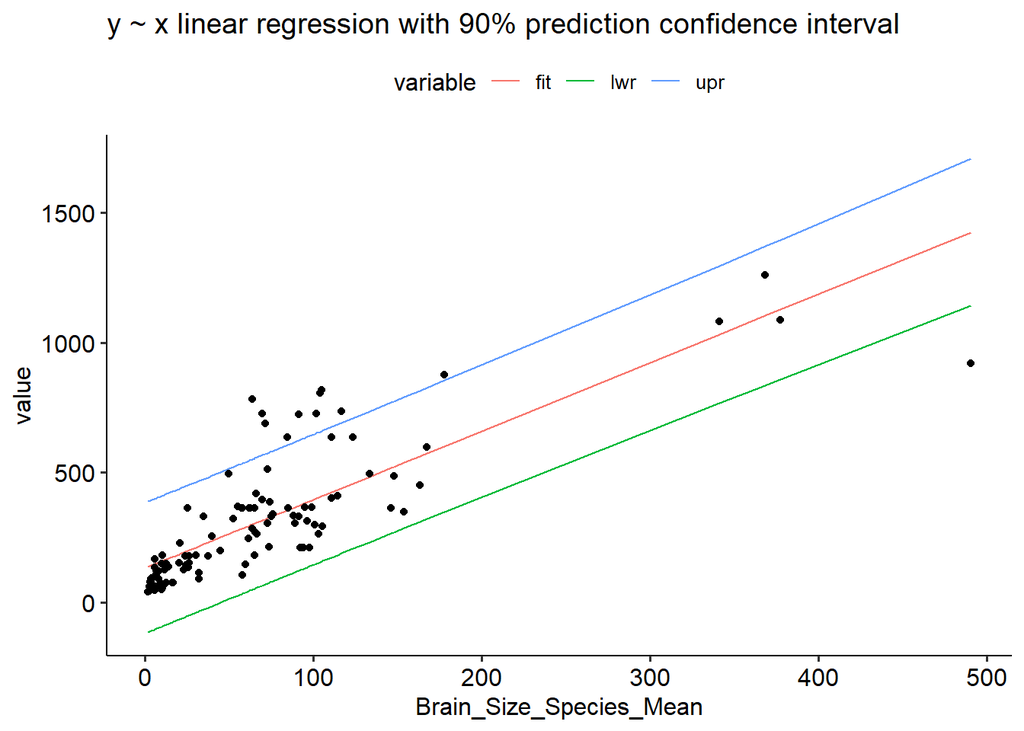

```r
p = data.frame(df_lm[['Brain_Size_Species_Mean']])
names(p) = 'Brain_Size_Species_Mean'
pi = predict(linear, newdata = p, interval = 'prediction', level = 0.9)
pi = cbind(df_lm$Brain_Size_Species_Mean, data.frame(pi))
names(pi) = c('Brain_Size_Species_Mean', 'fit', 'lwr', 'upr')
df_pi = melt(pi, id = 'Brain_Size_Species_Mean')

ggplot(data = df_pi) + geom_line(aes(x = Brain_Size_Species_Mean, y = value, color = variable)) +
  geom_point(data = df_lm, aes(x = Brain_Size_Species_Mean, y = WeaningAge_d)) +
  ggtitle("y ~ x linear regression with 90% prediction confidence interval")
```

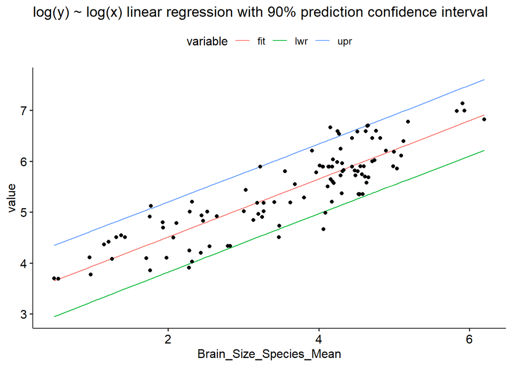

```r
p = data.frame(df_lm[['Brain_Size_Species_Mean']])
names(p) = 'Brain_Size_Species_Mean'
pi = predict(log_linear, newdata = p, interval = 'prediction', level = 0.9)
pi = cbind(log(p), data.frame(pi))
names(pi) = c('Brain_Size_Species_Mean', 'fit', 'lwr', 'upr')
df_pi = melt(pi, id = 'Brain_Size_Species_Mean')
ggplot(data = df_pi) + geom_line(aes(x = Brain_Size_Species_Mean, y = value, color = variable)) +
  geom_point(data = df_lm, aes(x = log(Brain_Size_Species_Mean), y = log(WeaningAge_d))) +
  ggtitle("log(y) ~ log(x) linear regression with 90% prediction confidence interval")
```

### 4

```r
pe = predict(linear, newdata = data.frame(Brain_Size_Species_Mean = 750),
                         interval = 'confidence', level = 0.9)
pe_log = exp(predict(log_linear, newdata = data.frame(Brain_Size_Species_Mean = 750),
                                  interval = 'confidence', level = 0.9))
print(paste("The prediction of 750 of regular model is ", toString(pe[[1]])))
```

```
## [1] "The prediction of 750 of regular model is  2110.29407281174"
```

```r
print(paste("The prediction of 750 of log model is ", toString(pe_log[[1]])))
```

```
## [1] "The prediction of 750 of log model is  1275.33886742041"
```

```r
print(paste("The prediction of lower band and upper band of 750 of regular model is ", toString(pe[c(2,3)])))
```

```
## [1] "The prediction of lower band and upper band of 750 of regular model is  1900.04033757323, 2320.54780805024"
```

```r
print(paste("The prediction of lower band and upper band of 750 of log model is ", toString(pe_log[c(2,3)])))
```

```
## [1] "The prediction of lower band and upper band of 750 of log model is  1079.01799518733, 1507.37914845508"
```

I will not trust these data, since it is far away from the mean of the X, and it is not a good idea to predict the value out of range of X range. The CI is too large to be trusted.

### 5

I think log model looks better, because with log transformation, the data distributed are more linear compared with regular model. And I think they are more normal distributed:

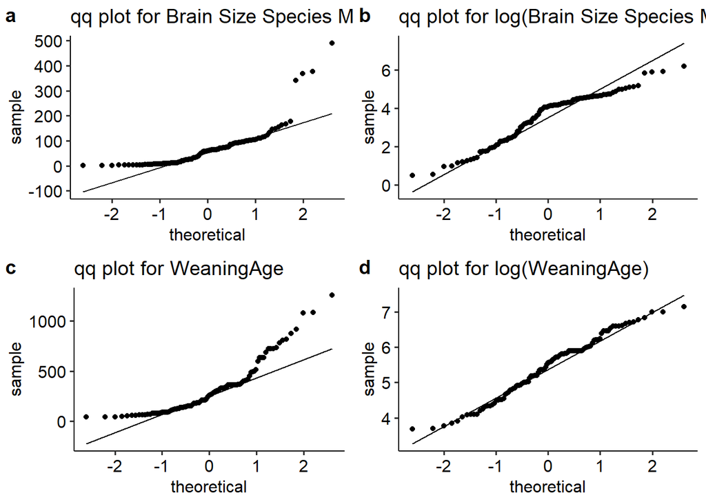

```r
a = ggplot(df_lm, aes(sample = Brain_Size_Species_Mean)) + stat_qq() + stat_qq_line() + ggtitle("qq plot for Brain Size Species Mean")

b = ggplot(df_lm, aes(sample = log(Brain_Size_Species_Mean))) + stat_qq() + stat_qq_line() + ggtitle("qq plot for log(Brain Size Species Mean)")

c = ggplot(df_lm, aes(sample = WeaningAge_d)) + stat_qq() + stat_qq_line() + ggtitle("qq plot for WeaningAge")

d = ggplot(df_lm, aes(sample = log(WeaningAge_d))) + stat_qq() + stat_qq_line() + ggtitle("qq plot for log(WeaningAge)")

ggarrange(a, b, c, d, labels = c('a', 'b', 'c', 'd'), ncol = 2, nrow = 2)
```

## challenge 2

We could use bootstrapping to estimate standard errors and confidence intervals around certain parameter values, we can also do the same for estimating standard errors and CIs around regression parameters.

### 1

run a linear regression looking at log(MeanGroupSize) ~ log(Body_mass_female_mean) and report coeffiecients (slope and intercept)

```r
linear = lm(log(MeanGroupSize) ~ log(Body_mass_female_mean), data = df)
linear[['coefficients']]
```

```
##                (Intercept) log(Body_mass_female_mean)
##                 -1.7772580                  0.5062813
```

### 2

use bootstrapping to sample from the dataset 1000 times with replacement, each time fitting the same model and calculating the appropriate coefficients. This generates a bootstrap sampling distribution for each coefficient. Plot a histogram of these sampling distributions.

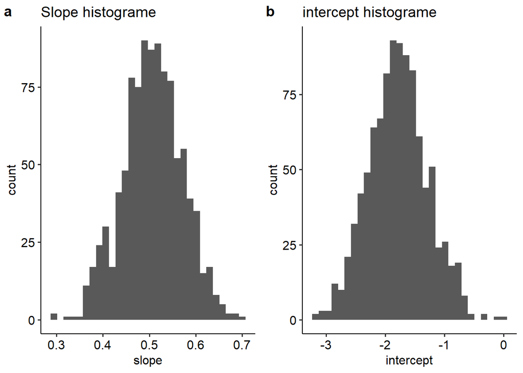

```r
df_n = df[c('MeanGroupSize', 'Body_mass_female_mean')] %>% drop_na()
slope = list()
intercept = list()
for (i in 1:1000){
  df_d = sample_n(df_n, nrow(df_n), replace = TRUE)
  linear_t = lm(log(MeanGroupSize) ~ log(Body_mass_female_mean), data = df_d)
  coef = linear_t[['coefficients']]
  intercept[[i]] = coef[['(Intercept)']]
  slope[[i]] = coef[['log(Body_mass_female_mean)']]
}
intercept = as.numeric(matrix(intercept))
slope = as.numeric(matrix(slope))
df_co = data.frame(intercept)
df_co[['slope']] = slope
a = ggplot(data = df_co, aes(x = slope)) + geom_histogram(bins = 30) + ggtitle("Slope histograme")
b = ggplot(data = df_co, aes(x = intercept)) + geom_histogram(bins = 30)+ ggtitle("intercept histograme")
ggarrange(a, b, labels = c('a', 'b'), ncol = 2, nrow = 1)
```

### 3

Estimate the standard error for coefficients as the standard deviation of the sampling distribution from your bootstrap.

```r
intercept_sd = sd(df_co[['intercept']])
slope_sd = sd(df_co[['slope']])
print(paste("std of intercept is ", intercept_sd))
```

```
## [1] "std of intercept is  0.494101402680244"
```

```r
print(paste("std of slope is ", slope_sd))
```

```
## [1] "std of slope is  0.0638252579785237"
```

### 4

Determine the 95% CI for coefficients based on the appropriate quantiles from sampling distribution.

```r
intercept_ci = quantile(df_co[['intercept']], probs = c(0.025, 0.975))
slope_ci = quantile(df_co[['slope']], probs = c(0.025, 0.975))
print(paste("CI of intercept is ", intercept_ci))
```

```
## [1] "CI of intercept is  -2.74160657335613"
## [2] "CI of intercept is  -0.787962885015229"
```

```r
print(paste("CI of slope is ", slope_ci))
```

```
## [1] "CI of slope is  0.377189213522656" "CI of slope is  0.63275782474101"
```

### 5

How do the SEs estimated from the bootstrap sampling distribution compare to those estimated mathematically as part of lm() function?

```r
summary(linear)[['coefficients']]
```

```
##                              Estimate Std. Error   t value     Pr(>|t|)
## (Intercept)                -1.7772580 0.43751572 -4.062158 8.061483e-05
## log(Body_mass_female_mean)  0.5062813 0.05562507  9.101674 8.078462e-16
```

The bootstrap sampling distribution std is very similar compared with etimated mathematical result from lm() function

### 6

How do bootstrap CIs compare to those estimated mathematically as part of the lm() function?

```r
 confint(linear, level = 0.95)
```

```
##                                 2.5 %     97.5 %
## (Intercept)                -2.6422501 -0.9122659
## log(Body_mass_female_mean)  0.3963075  0.6162550
```

The bootstrap sampling distribution CI is very similar compared with etimated mathematical result from lm() function

## Challenge 3

```r
boot_lm = function(d, model, conf.level = 0.95, reps = 1000){
  linear = lm(model, data = d)
  col_name = names(linear[['coefficients']])
  sum_linear = summary(linear)
  df_r = data.frame(sum_linear[['coefficients']][,c('Estimate', 'Std. Error')])
  df_co = data.frame(confint(linear, c(col_name), conf.level))
  df_r = merge(df_r, df_co, by = 0)
  names(df_r) = c("beta", "Estimate", "standard_error", "lower", "upper")
  coef = list()
  col_name = df_r$beta
  for (i in df_r$beta){
    coef[[i]] = list()
  }
  for (i in 1:reps){
    df_d = sample_n(d, nrow(df), replace = TRUE)
    linear_t = lm(model, data = df_d)
    for (col in col_name){
      coef[[col]][[i]] = linear_t[['coefficients']][[col]]
    }
  }
  df_f = data.frame(as.numeric(matrix(coef[[col_name[[1]]]])))
  names(df_f) = col_name[[1]]
  for (i in 2:length(col_name)){
    df_f[[col_name[[i]]]] = as.numeric(matrix(coef[[col_name[[i]]]]))
  }
  means = list()
  std = list()
  lower = list()
  upper = list()
  for (i in 1:length(col_name)){
    means[[i]] = mean(df_f[[i]])
    std[[i]] = sd(df_f[[i]])
    lower[[i]] = quantile(df_f[[col_name[[i]]]], probs = (1-conf.level) / 2)[[1]]
    upper[[i]] = quantile(df_f[[col_name[[i]]]], probs = 1 - (1 - conf.level)/2)[[1]]
  }
  df_r[['estimate_sample']] = unlist(means)
  df_r[['standard_error_sample']] = unlist(std)
  df_r[['lower_sample']] = unlist(lower)
  df_r[['upper_sample']] = unlist(upper)
  # print(class(df_r[['estimate_sample']]))
  return(df_r)
}
```

log(MeanGroupSize) ~ log(Body_mass_female_mean)

```r
res_1 = boot_lm(df, 'log(MeanGroupSize) ~ log(Body_mass_female_mean)')
res_1
```

```
##                         beta   Estimate standard_error      lower      upper
## 1                (Intercept) -1.7772580     0.43751572 -2.6422501 -0.9122659
## 2 log(Body_mass_female_mean)  0.5062813     0.05562507  0.3963075  0.6162550
##   estimate_sample standard_error_sample lower_sample upper_sample
## 1      -1.7884037            0.47010488   -2.6898559   -0.8295347
## 2       0.5081979            0.06006345    0.3825051    0.6254934
```

log(DayLength_km) ~ log(Body_mass_female_mean)

```r
res_2 = boot_lm(df, 'log(DayLength_km) ~ log(Body_mass_female_mean)')
res_2
```

```
##                         beta   Estimate standard_error       lower     upper
## 1                (Intercept) -0.1427624      0.4650068 -1.06510122 0.7795764
## 2 log(Body_mass_female_mean)  0.0389422      0.0566739 -0.07347022 0.1513546
##   estimate_sample standard_error_sample lower_sample upper_sample
## 1     -0.13530077            0.46802184  -1.03447354    0.7551746
## 2      0.03742187            0.05878717  -0.07848945    0.1502834
```

log(DayLength_km) ~ log(Body_mass_female_mean) + log(MeanGroupSize)

```r
res_3 = boot_lm(df, 'log(DayLength_km) ~ log(Body_mass_female_mean) + log(MeanGroupSize)')
res_3
```

```
##                         beta    Estimate standard_error      lower      upper
## 1                (Intercept) -0.29916271     0.48590764 -1.2649568 0.66663134
## 2 log(Body_mass_female_mean) -0.08813683     0.06421586 -0.2157728 0.03949915
## 3         log(MeanGroupSize)  0.46012782     0.07622217  0.3086280 0.61162764
##   estimate_sample standard_error_sample lower_sample upper_sample
## 1     -0.25990966            0.44213965   -1.0849717   0.61247269
## 2     -0.09457817            0.05779803   -0.2159938   0.02565877
## 3      0.46365339            0.09965663    0.2677220   0.65722353
```

## Extra credit

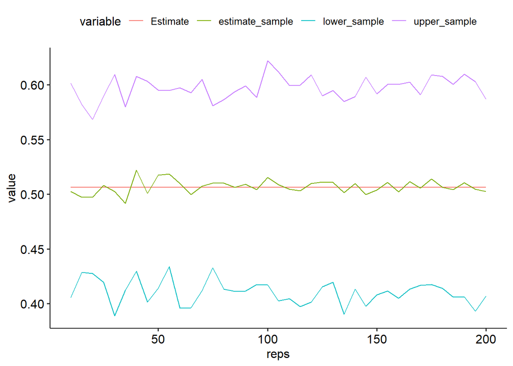

```r
df_drop = df[c('MeanGroupSize', 'Body_mass_female_mean')] %>%drop_na()
final = boot_lm(df_drop, 'log(MeanGroupSize) ~ log(Body_mass_female_mean)', reps = 10)
final = final[,c('beta', 'Estimate', 'estimate_sample', 'lower_sample', 'upper_sample')]
final[['reps']] = 10
for (i in 1:38){
  t = boot_lm(df_drop, 'log(MeanGroupSize) ~ log(Body_mass_female_mean)', reps = i * 5 + 10)
  t = t[,c('beta', 'Estimate', 'estimate_sample', 'lower_sample', 'upper_sample')]
  t[['reps']] = i * 5 + 10
  final = data.frame(rbind(final, t))
}
final = final %>% filter(beta == 'log(Body_mass_female_mean)')
final = final[, !names(final) %in% c('beta')]
final_m = melt(final, id = 'reps')
ggplot(data = final_m) + geom_line(aes(x = reps, y = value, color = variable))
```